# Bogotá D.C. Spatial Analysis

2023-06-08

### Diego Esteban Quintero Rey

### Ingeniería de Sistemas y Computación

### Introducción a la Biología Computacional, 2023-I

1. You have a .shp file called localidades_BOGOTA_DC.shp as a part of this tutorial. This file is the limit of the localities of Bogota DC. 1) Read this file using the function of the package rgdal to read .shp files, name this object as LOCALIDADES. 2) Read the raster SRTM_30_BOGOTA_DC_CLIP.tif, name this raster SRTM_30. 3) The standard deviation (sd) is considered a measure of the variation data; it means that higher sd of altitude (SRTM_30) suggests higher topographic variability. You must mask the SRTM_30 by each locality (LOCALIDADES) to estimate the sd of SRTM_30 by locality. What is the locality with the highest topographic variability? Note: You can use a loop or not, you decide.

```r
#install.packages("sp")
#install.packages("rgdal")
#install.packages("raster")
#install.packages("dismo")
#install.packages("rgeos")
#install.packages("car")

rm(list = ls(all.names = TRUE))
gc()
```

```
##          used (Mb) gc trigger (Mb) max used (Mb)
## Ncells 514460 27.5    1139687 60.9   660397 35.3
## Vcells 938899  7.2    8388608 64.0  1771347 13.6
```

```r
library("sp")
library("rgdal")
library("raster")
library("dismo")
library("rgeos")
library("car")
```

1. Read this file using the function of the package rgdal to read .shp files, name this object as LOCALIDADES.

```r
# reads the shapefile into a SpatialPolygonsDataFrame object called LOCALIDADES
LOCALIDADES = readOGR(dsn = "data", layer = "localidades_BOGOTA_DC")
```

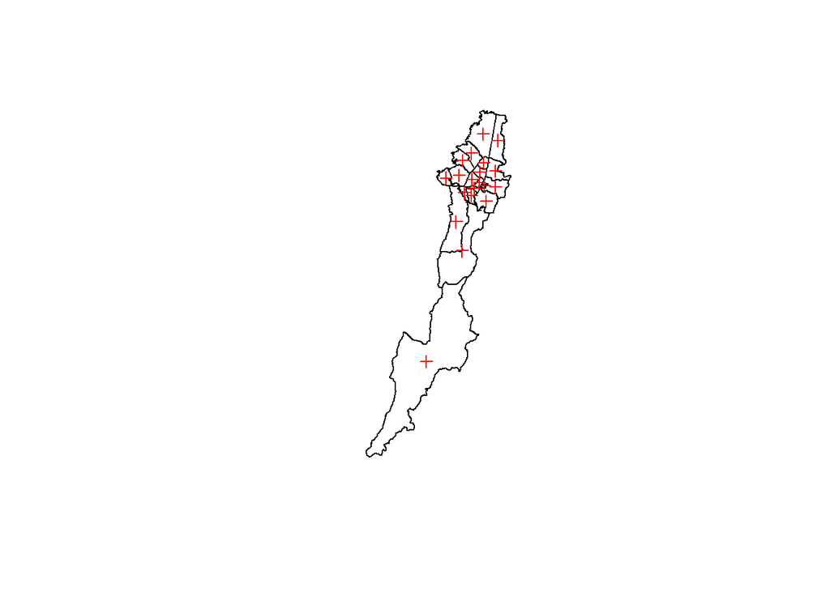

```r
# calculates the centroids of each locality
CENTROIDS = gCentroid(LOCALIDADES, byid=T)

# plots the LOCALIDADES polygons
plot(LOCALIDADES)

# adds the CENTROIDS points to the plot using the add = TRUE argument
plot(CENTROIDS, add=TRUE, col = "red")
```

2. Read the raster SRTM_30_BOGOTA_DC_CLIP.tif, name this raster SRTM_30.

```r
# creates a data frame called R_points from the CENTROIDS object, storing the longitude and latitude coordinates of the centroids
R_points = data.frame(CENTROIDS)

# assigns appropriate column names to the R_points data frame
names(R_points) = c("Long","Lat")

R_points
```

```
##         Long      Lat
## 0  -74.03622 4.593973
## 1  -74.07355 4.669567
## 2  -74.14015 4.678183
## 3  -74.11319 4.701126
## 4  -74.07207 4.596605
## 5  -74.03688 4.644983
## 6  -74.16196 4.482460
## 7  -74.07585 4.763208
## 8  -74.11336 4.566477
## 9  -74.15267 4.630347
## 10 -74.14281 4.390025
## 11 -74.08795 4.607156
## 12 -74.10284 4.588771
## 13 -74.08577 4.641174
## 14 -74.25698 4.036569
## 15 -74.06607 4.548749
## 16 -74.02782 4.742092
## 17 -74.13599 4.574841
## 18 -74.19439 4.621780
## 19 -74.11158 4.616245
```

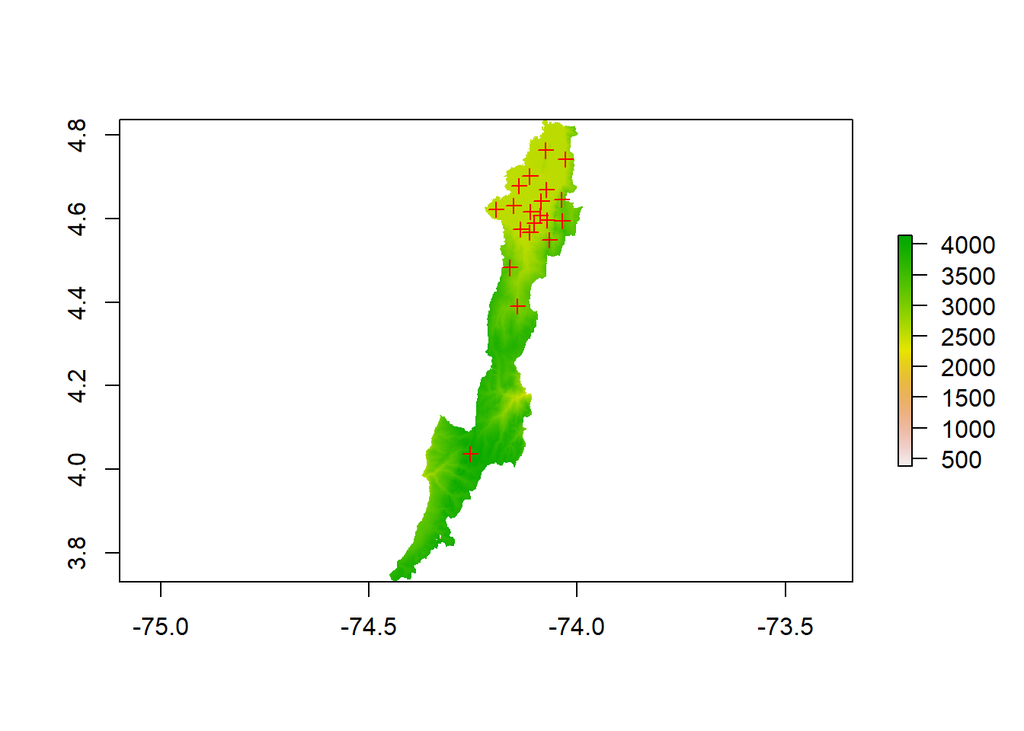

```r
# creates object for coordinate reference system (CRS) as WGS84
WGS84 = CRS("+proj=longlat +datum=WGS84 +no_defs +ellps=WGS84 +towgs84=0,0,0")

# creates a SpatialPointsDataFrame object from the R_points data frame
SPDF = SpatialPointsDataFrame(coords = R_points[,c("Long","Lat")], data = R_points, proj4string = WGS84)

# loads a raster file into a RasterLayer object called SRTM_30
SRTM_30 = raster("data/raster/SRTM_30_BOGOTA_DC_CLIP.tif")

plot(SRTM_30)

plot(SPDF, col="red", add=TRUE)
```

3. You must mask the SRTM_30 by each locality (LOCALIDADES) to estimate the sd of SRTM_30 by locality.

```r
# creates buffer polygons around each point in the SPDF object using the gBuffer
# function, with a buffer width of 0.01 (in the same units as the CRS)
BUFFERS <- gBuffer(SPDF, width = 0.01, byid = TRUE)
```

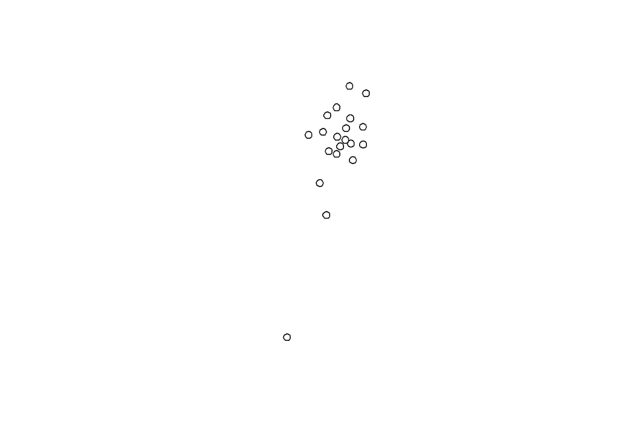

```r
# plots the BUFFERS polygons
plot(BUFFERS)
```

```r
# adds a new column called "ID" to the BUFFERS object,
# assigning sequential IDs from 0 to 19
BUFFERS$ID = seq(0, 19, 1)

head(BUFFERS)
```

```
##        Long      Lat ID
## 0 -74.03622 4.593973  0
## 1 -74.07355 4.669567  1
## 2 -74.14015 4.678183  2
## 3 -74.11319 4.701126  3
## 4 -74.07207 4.596605  4
## 5 -74.03688 4.644983  5
```

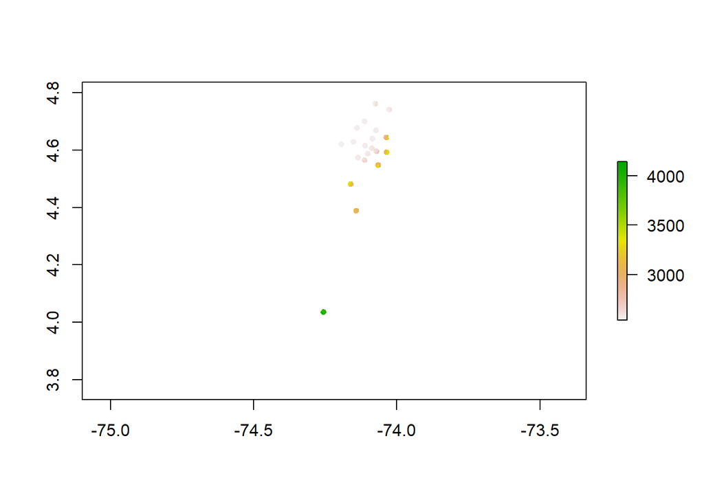

```r
# masks the SRTM_30 raster with the BUFFERS polygons using the mask function,
# creating a new raster object called mask
mask = mask(SRTM_30, BUFFERS)

plot(mask)
```

```r
# splits the BUFFERS object into subsets
# based on the unique values in the ID column
SUBSETS <- split(BUFFERS, BUFFERS$ID)

# applies anonymous function to SUBSETS list
results <- sapply(SUBSETS, function(subset) {
  mask_subset <- mask(SRTM_30, subset)
  values_subset <- getValues(mask_subset)
  sd_subset <- sd(values_subset, na.rm = TRUE) # excludes any missing values (NAs)
  return(sd_subset)
})

# vector, which contains the standard deviations
# calculated for each subset in the SUBSETS list
results
```

```
##          0          1          2          3          4          5          6
## 132.246031   2.950944   2.181825   2.650876  58.586104 137.359891 109.041483
##          7          8          9         10         11         12         13
##  31.671963  33.357388   4.650632  46.028036   7.640193   5.871319   3.525567
##         14         15         16         17         18         19
##  69.998093 131.628104  27.612861   3.805126   2.728244   2.032375
```

4. What is the locality with the highest topographic variability?

Answer: Chapinero

```r
# Get the names of the localidades from the LOCALIDADES object
localidades_names <- LOCALIDADES$Nombre_de_l

# Combine the names and results vectors into a data frame
results_df <- data.frame(localidades_names, results)

# Order the data frame by the results column in descending order
results_df <- results_df[order(results_df$results, decreasing = TRUE), ]

# Give names to the columns
colnames(results_df) <- c("Localidades", "Standard Deviation")

# Print the ordered localidades names
print(results_df)
```

```
##           Localidades Standard Deviation
## 5           CHAPINERO         137.359891
## 0            SANTA FE         132.246031
## 15      SAN CRISTOBAL         131.628104
## 6      CIUDAD BOLIVAR         109.041483
## 14            SUMAPAZ          69.998093
## 4          CANDELARIA          58.586104
## 10               USME          46.028036
## 8  RAFAEL URIBE URIBE          33.357388
## 7                SUBA          31.671963
## 16            USAQUEN          27.612861
## 11       LOS MARTIRES           7.640193
## 12     ANTONIO NARIÑO           5.871319
## 9             KENNEDY           4.650632
## 17         TUNJUELITO           3.805126
## 13        TEUSAQUILLO           3.525567
## 1      BARRIOS UNIDOS           2.950944
## 18               BOSA           2.728244
## 3            ENGATIVA           2.650876
## 2            FONTIBON           2.181825
## 19      PUENTE ARANDA           2.032375
```